# Reproducible Research: Peer Assessment 2

Barrie D. Fitzgerald  
January 22, 2015

## Severe Weather and the Impact on the United States’ Public Health and Economy

### Synposis

This analysis attempts to examine data collected from United States National Oceanic and Atmospheric Administration (NOAA) to determine the impact of the weather within the United States on the public health and economy. The data collected by NOAA ranges from 1950 to 2011; however, for this analysis the data was filtered down to a 15-year trend (1997-2011) to provide a relevant analysis for planning purposes. In terms of the public health, fatalities largely are resulted from excessive heat and tornadoes, while injuries are tornadoes and floods. The economic impact in terms of property damage largely comes from thunderstorms winds, flash floods, and tornadoes. Important to note, especially for the rural agricultural locations, e.g., Southern and Mid-western states, the economic impact, in terms of crop damage, stems from hail, flash floods, and floods.

### Data Processing

#### Basic Settings

First, we establish the working directory, locate the file needed, set data options, and load any libraries used.

```r
## Set ups
setwd("C:/Users/bdfitzgerald/Desktop/Data Science Specialist/RepData_PeerAssessment2")
file <- list.files("data", full.names = TRUE)
        ## libraries used
options(scipen = 1)
library(lubridate)
library(ggplot2)
library(gridExtra)
library(plyr)
```

##### Pulling in the dataset

Load the data file into R to begin the analysis.

```r
## importing the data file
## NOTE the cache needs to be "cache = TRUE"
stormdata <- read.csv(file)
```

##### Structure of data

Examine the basic structure of the data.

```r
## Understanding basics of data before data clean up
        ## data dimensions
dim(stormdata)
```

```
## [1] 902297     37
```

```r
        ## data class
sapply(stormdata, class)
```

```
##    STATE__   BGN_DATE   BGN_TIME  TIME_ZONE     COUNTY COUNTYNAME
##  "numeric"   "factor"   "factor"   "factor"  "numeric"   "factor"
##      STATE     EVTYPE  BGN_RANGE    BGN_AZI BGN_LOCATI   END_DATE
##   "factor"   "factor"  "numeric"   "factor"   "factor"   "factor"
##   END_TIME COUNTY_END COUNTYENDN  END_RANGE    END_AZI END_LOCATI
##   "factor"  "numeric"  "logical"  "numeric"   "factor"   "factor"
##     LENGTH      WIDTH          F        MAG FATALITIES   INJURIES
##  "numeric"  "numeric"  "integer"  "numeric"  "numeric"  "numeric"
##    PROPDMG PROPDMGEXP    CROPDMG CROPDMGEXP        WFO STATEOFFIC
##  "numeric"   "factor"  "numeric"   "factor"   "factor"   "factor"
##  ZONENAMES   LATITUDE  LONGITUDE LATITUDE_E LONGITUDE_    REMARKS
##   "factor"  "numeric"  "numeric"  "numeric"  "numeric"   "factor"
##     REFNUM
##  "numeric"
```

```r
        ## first two rows
head(stormdata, 2)
```

```
##   STATE__          BGN_DATE BGN_TIME TIME_ZONE COUNTY COUNTYNAME STATE
## 1       1 4/18/1950 0:00:00     0130       CST     97     MOBILE    AL
## 2       1 4/18/1950 0:00:00     0145       CST      3    BALDWIN    AL
##    EVTYPE BGN_RANGE BGN_AZI BGN_LOCATI END_DATE END_TIME COUNTY_END
## 1 TORNADO         0                                               0
## 2 TORNADO         0                                               0
##   COUNTYENDN END_RANGE END_AZI END_LOCATI LENGTH WIDTH F MAG FATALITIES
## 1         NA         0                        14   100 3   0          0
## 2         NA         0                         2   150 2   0          0
##   INJURIES PROPDMG PROPDMGEXP CROPDMG CROPDMGEXP WFO STATEOFFIC ZONENAMES
## 1       15    25.0          K       0
## 2        0     2.5          K       0
##   LATITUDE LONGITUDE LATITUDE_E LONGITUDE_ REMARKS REFNUM
## 1     3040      8812       3051       8806              1
## 2     3042      8755          0          0              2
```

##### Cleaning up the evotypes

Quick analysis of the event types (EVTYPES) there was inconsistency in the capitalization of the events. HAIL and hail would be listed, which would cause multiple responses. To combat this issue, all event types were lower-cased so that the aggregation would produce decent results.

```r
## Since using EVTYPE as the primiary incident
        ## Number of unique incidents
length(unique(stormdata$EVTYPE))
```

```
## [1] 985
```

```r
        ## examining notice no consistency in the EVTYPE...some are all caps, some not, some have a space before them
        ## adjusting the EVTYPE to have consistency in the data
evtypes <- tolower(stormdata$EVTYPE)
evtypes <- gsub("[[:blank:][:punct:]+]", " ", evtypes)
stormdata$EVTYPE <- evtypes
```

##### Events over the course of the years

The number of years the data was collected for the four categories were analyzed to determine if the data set needs to be filtered down to a more relevant trend.

```r
## BY year
stormdata$YEAR <- as.numeric(format(as.Date(stormdata$BGN_DATE, format = "%m/%d/%Y %H:%M:%S"), "%Y"))
fatal_year <- aggregate(stormdata$FATALITIES, by = list(DATE = stormdata$YEAR), sum, na.rm = TRUE)
colnames(fatal_year)[2] <- "FATALITIES"
injury_year <- aggregate(stormdata$INJURIES, by = list(DATE = stormdata$YEAR), sum, na.rm = TRUE)
colnames(injury_year)[2] <- "INJURIES"
prop_year <- aggregate(stormdata$PROPDMG, by = list(DATE = stormdata$YEAR), sum, na.rm = TRUE)
colnames(prop_year)[2] <- "PROP_DMG"
crop_year <- aggregate(stormdata$CROPDMG, by = list(DATE = stormdata$YEAR), sum, na.rm = TRUE)
colnames(crop_year)[2] <- "CROP_DMG"
        ## Charts
fat_year <- ggplot(fatal_year, aes(x = DATE, y = FATALITIES)) +
        geom_line(size = 1, color = "firebrick") +
        ylim(min(fatal_year$FATALITIES), max(fatal_year$FATALITIES)) +
        xlab("Year") +
        ylab("Number of Fatalities") +
        ggtitle("Number of Fatalities from 1950 to 2011") +
        theme(plot.title = element_text(size = 10, face = "bold"))
inj_year <- ggplot(injury_year, aes(x = DATE, y = INJURIES)) +
        geom_line(size = 1, color = "firebrick") +
        ylim(min(injury_year$INJURIES), max(injury_year$INJURIES)) +
        xlab("Year") +
        ylab("Number of Injuries") +
        ggtitle("Number of Injuries from 1950 to 2011") +
        theme(legend.position = "none", plot.title = element_text(size = 10, face = "bold"))
propdmg_year <- ggplot(prop_year, aes(x = DATE, y = PROP_DMG)) +
        geom_line(size = 1, color = "firebrick") +
        ylim(min(prop_year$PROP_DMG), max(prop_year$PROP_DMG)) +
        xlab("Year") +
        ylab("Total Property Damage") +
        ggtitle("Amount of Property Damage from 1950 to 2011") +
        theme(plot.title = element_text(size = 10, face = "bold"))
cropdmg_year <- ggplot(crop_year, aes(x = DATE, y = CROP_DMG)) +
        geom_line(size = 1, color = "firebrick") +
        ylim(min(crop_year$CROP_DMG), max(crop_year$CROP_DMG)) +
        xlab("Year") +
        ylab("Total Crop Damage") +
        ggtitle("Amount of Crop Damage from 1950 to 2011") +
        theme(legend.position = "none", plot.title = element_text(size = 10, face = "bold"))
```

Exhibit 1 shows that years that the data was available and the years that the data was started to be collected. For example in the Crop Damage chart data wasn’t collected until 1993. Upon examination of all line charts, there seemed to have been a spike in the amount of data collected regarding fatalities, injuries, property damage, and crop damage.

**Exhibit 1: Years of Data Collection for Fatalities, Injuries, Property Damage, and Crop Damage**

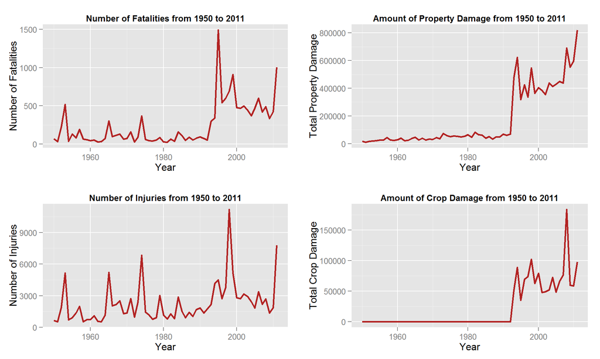

```r
grid.arrange(fat_year, propdmg_year, inj_year, cropdmg_year, ncol = 2)
```

##### Narrowing dataset to a relevant trend

The data set narrowed down to provide an relevant current analysis of the trends. Including data from the 1950 would not particularly have relevance as there was only specific events recorded. The data was narrowed down to a 15-year trend, starting at 1997 to 2011.

```r
## Note this will need to be CACHE = TRUE
## creating a 15 yr trend 1997 to 20111
stormdata <- subset(stormdata, stormdata$YEAR >= 1997, )
```

This generates the totals for each of the four categories.

```r
total_fat <- aggregate(stormdata$FATALITIES, by = list(Year = stormdata$YEAR), sum, na.rm = TRUE)
total_inj <- aggregate(stormdata$INJURIES, by = list(Year = stormdata$YEAR), sum, na.rm = TRUE)
total_prop <- round(aggregate(stormdata$PROPDMG, by = list(Year = stormdata$YEAR), sum, na.rm = TRUE), 0)
total_crop <- round(aggregate(stormdata$CROPDMG, by = list(Year = stormdata$YEAR), sum, na.rm = TRUE), 0)
total <- cbind(total_fat, total_inj[,2], total_prop[,2], total_crop[,2])
colnames(total)[2:5] <- c("Fatalities", "Injuries", "Property Damage (in dollars)", "Crop Damage (in dollars)")
total[,2:5] <- format(total[,2:5], big.mark = ",")
```

**Exhibit 2: Total Fatalities, Injuries, Property Damage, and Crop Damage, 1997-2011**

```r
knitr::kable(total)
```

| Year | Fatalities | Injuries | Property Damage (in dollars) | Crop Damage (in dollars) |
| --- | --- | --- | --- | --- |
| 1997 | 601 | 3,800 | 338,000 | 74,075 |
| 1998 | 687 | 11,177 | 545,845 | 102,235 |
| 1999 | 908 | 5,148 | 364,612 | 62,707 |
| 2000 | 477 | 2,803 | 403,471 | 79,414 |
| 2001 | 469 | 2,721 | 383,597 | 48,248 |
| 2002 | 498 | 3,155 | 355,741 | 49,231 |
| 2003 | 443 | 2,931 | 437,755 | 52,322 |
| 2004 | 370 | 2,426 | 412,838 | 72,439 |
| 2005 | 469 | 1,834 | 428,309 | 48,443 |
| 2006 | 599 | 3,368 | 449,584 | 65,851 |
| 2007 | 421 | 2,191 | 438,170 | 76,768 |
| 2008 | 488 | 2,703 | 690,246 | 183,821 |
| 2009 | 333 | 1,354 | 553,433 | 59,683 |
| 2010 | 425 | 1,855 | 594,848 | 59,014 |
| 2011 | 1,002 | 7,792 | 820,291 | 98,311 |

This generates the total by event type and selects the 10 highest events.

```r
## By EVTYPE charts
        ## fatal
fatal <- aggregate(stormdata$FATALITIES, by = list(EVTYPE = stormdata$EVTYPE), sum, na.rm = TRUE)
colnames(fatal)[2] <- "FATALITIES"
fatal <- subset(fatal, fatal$FATALITIES > 0,)
        ## injury
injury <- aggregate(stormdata$INJURIES, by = list(EVTYPE = stormdata$EVTYPE), sum, na.rm = TRUE)
colnames(injury)[2] <- "INJURIES"
injury <- subset(injury, injury$INJURIES > 0,)
        ## property damage
prop_damage <- aggregate(stormdata$PROPDMG, by = list(EVTYPE = stormdata$EVTYPE), sum, na.rm = TRUE)
colnames(prop_damage)[2] <- "PROP_DAMAGE"
prop_damage <- subset(prop_damage, prop_damage$PROP_DAMAGE > 0,)
        ## crop damage
crop_damage <- aggregate(stormdata$CROPDMG, by = list(EVTYPE = stormdata$EVTYPE), sum, na.rm = TRUE)
colnames(crop_damage)[2] <- "CROP_DAMAGE"
crop_damage <- subset(crop_damage, crop_damage$CROP_DAMAGE > 0, )
        ## top 10
fatal_top10 <- head(arrange(fatal, -FATALITIES), 10)
injury_top10 <- head(arrange(injury, -INJURIES), 10)
prop_damage10 <- head(arrange(prop_damage, -PROP_DAMAGE), 10)
prop_damage10$PROP_DAMAGE <- round(prop_damage10$PROP_DAMAGE, 0)
crop_damage10 <- head(arrange(crop_damage, -CROP_DAMAGE), 10)
crop_damage10$CROP_DAMAGE <- round(crop_damage10$CROP_DAMAGE, 0)
```

### Results

```r
## Top charts
fat_10 <- ggplot(fatal_top10, aes(x = reorder(EVTYPE, FATALITIES), y = FATALITIES)) +
        geom_bar(stat = "identity", fill = "firebrick", color = "firebrick") +
        coord_flip() +
        ylab("Number of Fatalities") +
        xlab("Event Type") +
        ggtitle("10 Highest Events Resulting in Fatalities") +
        theme(legend.position = "none", plot.title = element_text(size = 10, face = "bold"))
inj_10 <- ggplot(injury_top10, aes(x = reorder(EVTYPE, INJURIES), y = INJURIES)) +
        geom_bar(stat = "identity", fill = "firebrick", color = "firebrick") +
        coord_flip() +
        ylab("Number of Injuries") +
        xlab("Event Type") +
        ggtitle("10 Highest Events Resulting in Injuries") +
        theme(legend.position = "none", plot.title = element_text(size = 10, face = "bold"))
prop_10 <- ggplot(prop_damage10, aes(x = reorder(EVTYPE, PROP_DAMAGE), y = log10(PROP_DAMAGE))) +
        geom_bar(stat = "identity", fill = "firebrick", color = "firebrick") +
        coord_flip() +
        ylab("Amount of Property Damage (based on log-scale)") +
        xlab("Event Type") +
        ggtitle("10 Highest Events Resulting in Property Damage") +
        theme(legend.position = "none", plot.title = element_text(size = 10, face = "bold"))
crop_10 <- ggplot(crop_damage10, aes(x = reorder(EVTYPE, CROP_DAMAGE), y = log10(CROP_DAMAGE))) +
        geom_bar(stat = "identity", fill = "firebrick", color = "firebrick") +
        coord_flip() +
        ylab("Amount of Property Damage (based on log-scale)") +
        xlab("Event Type") +
        ggtitle("10 Highest Events Resulting in Crop Damage") +
        theme(legend.position = "none", plot.title = element_text(size = 10, face = "bold"))
```

Exhibit 3 displays the 10 highest events resulting in an impact on the public health and economy. Of the public health, a large number of fatalities seem to stem from excessive heat followed by tornadoes, while injuries seem to stem from tornadoes followed by floods. For the impact of the economy, the property damage largely result from tstm winds, flash floods, and/or tornadoes, while crops seem to be largely damaged by hail, flash floods, and/or floods.

**Exhibit 3: 10 Highest Events Resulting in Fatalities, Injuries, Property Damage, and Crop Damage, 1997-2011**

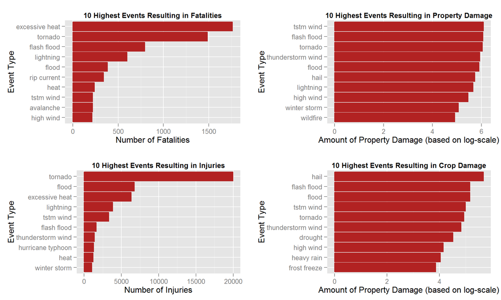

```r
grid.arrange(fat_10, prop_10, inj_10, crop_10, ncol = 2)
```

### Further Analysis

Further analysis will need or should be conducted to combine event types in related categories to see how the related categories impact the public health and economy of the United States.